# 9. 記述統計学

Masahiko Asano

2026-06-15

# 1. 統計学の種類

- 統計学は記述統計学 (`descriptive statistics`) と推測統計学 (`inferential statistics`) の二つに分類できる

| **統計学の種類** | **特徴** |
| --- | --- |
| **記述統計学**: | **統計量を使ってデータ傾向や性質をつかむ** |
| 推測統計学: | 母集団の母数（母平均や母分散）を検定し推定する |

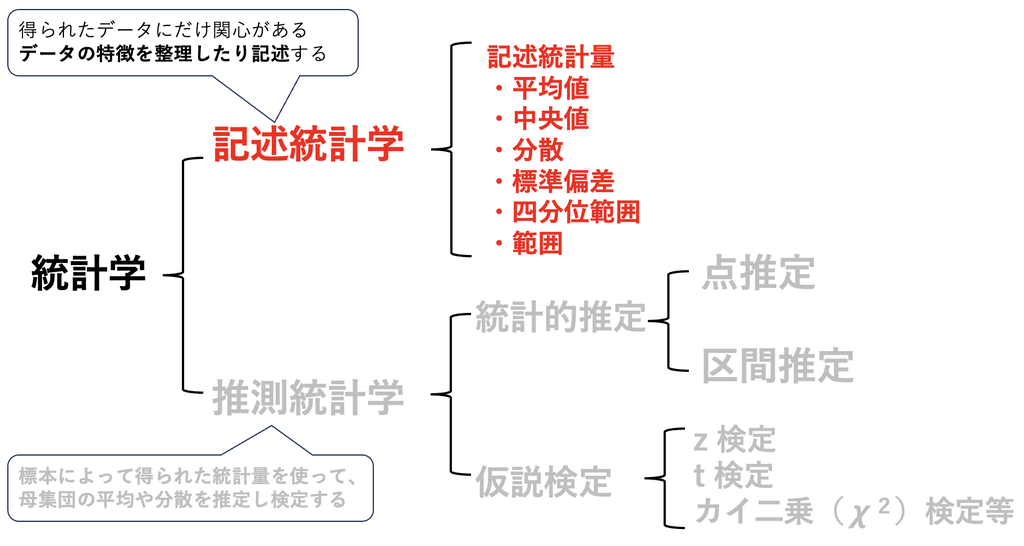

#### 記述統計学

- 集めたデータの統計量（平均、分散、標準偏差など）を計算して、そのデータを我々が理解できるような形で記述し要約する
- データの分布を明らかにすることで、データ傾向や性質をつかむための統計手法

#### 推測統計学

- 入手可能な記述統計量を使って未観測の事象を予測、推定するスキルが「推測統計学」
- 母集団 (`population`) から標本 (`sample`) を無作為に抽出し、その**標本によって得られた標本平均や不偏分散などの統計量を使って、母集団の母数（母平均や母分散）を検定し推定する**
- 推測統計学の基本的な考えは、**母集団からランダムに抽出した標本を増やし、無限に試行を繰り返せば、全体の一部である標本から、巨大で未知の母集団を推測できる**、ということ
- 推測統計学では、分析対象が**確率分布**すると考える

・ここでは両統計学で共通して使う基礎知識である「記述統計学」を解説・演習する

# 2. 記述統計量

- 記述統計量(`descriptive statistics`)とは「ある変数が持つ情報を要約した数値」

#### 代表的な記述統計量

[output not shown]

注1: 「不偏分散」と「不偏標準偏差」の詳細に関しては「`10.推測統計学`」での解説を参照

注2: 四分位範囲とは、75パーセンタイルと25パーセンタイルの差のこと

```r
x <- c(22, 33, 44, 55, 66, 77, 88, 99, 100)
x
```

```
[1]  22  33  44  55  66  77  88  99 100
```

- `x` を代表する値（=代表値）として平均値、中央値、分散、標準偏差、四分位範囲、範囲を求めてみる

## 2.1 平均値

- 変数$x$ の平均$\bar{x}$ は次の式で求めることができる:
  $$\bar{x} = \frac{\sum_{i=1}^n
  x_i}{n}$$

#### R を使って平均点を計算する方法①

- 最も手間の掛かる方法

```r
(22 + 33 + 44 + 55 + 66 + 77 + 88 + 99 + 100) / 9
```

```
[1] 64.88889
```

#### R を使って平均点を計算する方法②

- `sum( )` を使う

```r
sum(x / 9)
```

```
[1] 64.88889
```

#### R を使って平均点を計算する方法③

- `mean( )関数` を使う

```r
mean(x)
```

```
[1] 64.88889
```

#### R を使って平均点を計算する方法④

- `summary()関数`を使う

```r
summary(x)
```

```
   Min. 1st Qu.  Median    Mean 3rd Qu.    Max.
  22.00   44.00   66.00   64.89   88.00  100.00
```

## 2.2 中央値（真ん中の値）

```r
median(x)
```

```
[1] 66
```

- `x` を小さい順にソートしてみる

```r
sort(x)
```

```
[1]  22  33  44  55  66  77  88  99 100
```

- 66 が真ん中にある（＝中央値）だとわかる

## 2.3 分散（ばらつき）

- 分散 (`variance`) とは数値データのばらつき具合を表すための指標
- 分散は**「平均値と個々のデータの差の２乗の平均」**
- 平均値から離れた値をとるデータが多い → 分散が大きい
- 平均点付近の値をとるデータ多い → 分散が小さい

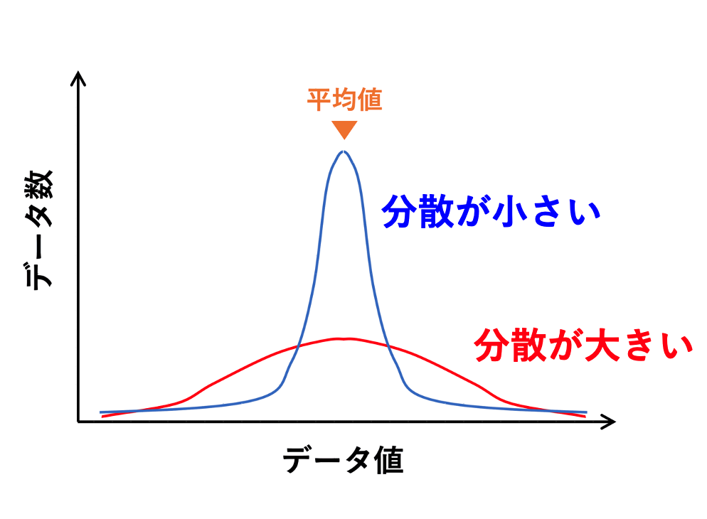

#### 分散

- 一般的に分散は次の式で求められる
  $$分散 = \frac{\sum_{i=1}^N (個々のデータ -
  平均)^2}{N}$$
- 分散 $σ^2$（シグマ）は次のように表記されることが多い
  $$σ^2 = \frac{\sum_{i=1}^N (x_i -
  \bar{x})^2}{N}$$

#### 分散を計算してみる

```r
x
```

```
[1]  22  33  44  55  66  77  88  99 100
```

- `x` の平均値を求めて `x_mean` と名前を付ける

```r
x_mean <- mean(x)
x_mean
```

```
[1] 64.88889
```

- 平均からの**「偏差」**（個々のデータ - 平均）を計算して `x1` と名前を付ける

```r
x1 <- x - x_mean
x1
```

```
[1] -42.888889 -31.888889 -20.888889  -9.888889   1.111111  12.111111  23.111111
[8]  34.111111  35.111111
```

- 例えば、`[1]`の右隣にある数値 (`-42.888889`) は、データ `x` の 1 番目の値 (`22`) から平均値 (`64.88889`) を引いた値

```r
22 - 64.88889
```

```
[1] -42.88889
```

- これが「平均からの偏差 (`x1`)」
- 次に「平均からの偏差」を 2 乗して `x2` と名付ける

```r
x2 <- x1^2
x2
```

```
[1] 1839.456790 1016.901235  436.345679   97.790123    1.234568  146.679012
[7]  534.123457 1163.567901 1232.790123
```

- `x2` の和を計算し `sum_x2` と名付ける

```r
sum_x2 <- sum(x2)
sum_x2
```

```
[1] 6468.889
```

- これで分散を求める式の分子は完成
- 分母の数 (`N`) は 9 を代入する
- `x` の分散 $σ^2$ は次のように計算できる

$$σ^2 = \frac{\sum_{i=1}^N (x_i -
\bar{x})^2}{N} = \frac{6468.889}{9} = 718.77$$

#### R関数 `var()` を使って分散を求めてみる

```r
var(x)
```

```
[1] 808.6111
```

#### 上で求めた分散 `(718.77`) とは異なる値が出た

→ その理由： `var()` が計算するのは「**分散 $σ^2$**」 ではなく**「不偏分散 $U^2$」**だから  
→ 詳細は `10. 推測統計学` を参照

## 2.4 標準偏差（ばらつき）

- 標準偏差は分散の平方根

$$標準偏差 = \sqrt{分散}$$

- 分散は、計算する過程で 2 乗されている  
  → 本来の単位ではない  
  → 数値の意味が変わってしまう
- 平方根をとることによって単位を揃えて標準偏差を計算する

```r
sqrt(718.77)
```

```
[1] 26.80989
```

#### R関数 `var()` の平方根を使って標準偏差を求めてみる

```r
sqrt(var(x))
```

```
[1] 28.43609
```

#### R関数 `sd()`を使って標準偏差を求めてみる

```r
sd(x)
```

```
[1] 28.43609
```

→ その理由： `sqrt(var(x))` や `sd(x)` が計算するのは「**標準偏差 $σ$**」 ではなく**「不偏標準偏差 $U$」**だから  
→ 詳細は `10. 推測統計学` を参照

## 2.5 四分位範囲

- データの75パーセンタイル (`3rd Qu.`) と25パーセンタイル (`1st Qu.`) の差

```r
IQR(x)
```

```
[1] 44
```

## 2.6 範囲

```r
max(x, na.rm = TRUE) - min(x)
```

```
[1] 78
```

## 2.7 記述統計をまとめて表示: `summary()`

- 変数 `x` の統計量のサマリーを表示させる

```r
summary(x)
```

```
   Min. 1st Qu.  Median    Mean 3rd Qu.    Max.
  22.00   44.00   66.00   64.89   88.00  100.00
```

- ここでは変数ごとに次の情報が表示されている

| **記述統計量** | **解説** |
| --- | --- |
| Min: | 最小値 |
| 1st Qu.: | 1st Quantile (25%) |
| Median: | 中央値 (50%) |
| Mean: | 平均値 |
| 3rd Qu: | 3rd Quantile (75%) |
| Max: | 最大値 |

# 3. `dplyr`を用いた記述統計量

- `dplyr`パッケージを含む `tidyverse` パッケージをロード

```r
library(tidyverse)
```

データの準備 (`hr96-26.csv`) ・hr96-26.csv をクリックしてデータをパソコンにダウンロード

- `RProject` フォルダ内に **data** という名称のフォルダを作成する
- ダウンロードした `hr96-26.csv` を手動で`RProject` フォルダ内にある **data** フォルダに入れる
- 選挙データの読み取る
- `na = "."` は「dot は欠損値と理解せよ」とのコマンド

```r
hr <- read_csv("data/hr96-26.csv",
               na = ".")  # 欠損値処理
```

- `hr96-26.csv` は1996年に衆院選挙に小選挙区が導入されて以来実施された 11 回の衆議院選挙（1996, 2000, 2003, 2005, 2009, 2012, 2014, 2017, 2021, 2024, 2026）の結果のデータ
- 読み取った選挙データを確認
- `dim()` 関数を使うと `hr` は11,892行、22列のデータであることが分かる

```r
dim(hr)
```

```
[1] 11892    22
```

[output not shown]

### `dfSummary()` を使った記述統計の可視化

- `summarytools パッケージ`を読み込む

```r
library(summarytools)
```

#### `hr` に含まれている変数を可視化する

- `year`, `kun`, `wl`, `rank`, `status`, を `factor` に変換する

```r
hr$year <- as.factor(hr$year)
hr$kun <- as.factor(hr$kun)
hr$wl <- as.factor(hr$wl)
hr$rank <- as.factor(hr$rank)
hr$status <- as.factor(hr$status)
```

```r
dfSummary(hr,
          style = "grid", plain.ascii = FALSE,
            graph.magnif = 0.75, valid.col = FALSE, tmp.img.dir = "/tmp")
```

### Data Frame Summary

#### hr

**Dimensions:** 11892 x 22  
**Duplicates:** 0

No

Variable

Stats / Values

Freqs (% of Valid)

Graph

Missing

1

year  
[factor]

1. 1996  
2. 2000  
3. 2003  
4. 2005  
5. 2009  
6. 2012  
7. 2014  
8. 2017  
9. 2021  
10. 2024  
11. 2026

1261 (10.6%)  
1199 (10.1%)  
1026 ( 8.6%)  
989 ( 8.3%)  
1139 ( 9.6%)  
1294 (10.9%)  
959 ( 8.1%)  
936 ( 7.9%)  
857 ( 7.2%)  
1113 ( 9.4%)  
1119 ( 9.4%)

0  
(0.0%)

2

pref  
[character]

1. 東京  
2. 大阪  
3. 神奈川  
4. 愛知  
5. 埼玉  
6. 千葉  
7. 兵庫  
8. 福岡  
9. 北海道  
10. 静岡  
[ 37 others ]

1251 (10.5%)  
796 ( 6.7%)  
787 ( 6.6%)  
650 ( 5.5%)  
619 ( 5.2%)  
556 ( 4.7%)  
516 ( 4.3%)  
447 ( 3.8%)  
446 ( 3.8%)  
319 ( 2.7%)  
5505 (46.3%)

0  
(0.0%)

3

ku  
[character]

1. tokyo  
2. osaka  
3. kanagawa  
4. aichi  
5. saitama  
6. chiba  
7. hyogo  
8. fukuoka  
9. hokkaido  
10. shizuoka  
[ 37 others ]

1251 (10.5%)  
796 ( 6.7%)  
787 ( 6.6%)  
650 ( 5.5%)  
619 ( 5.2%)  
556 ( 4.7%)  
516 ( 4.3%)  
447 ( 3.8%)  
446 ( 3.8%)  
319 ( 2.7%)  
5505 (46.3%)

0  
(0.0%)

4

kun  
[factor]

1. 1  
2. 2  
3. 3  
4. 4  
5. 5  
6. 6  
7. 7  
8. 8  
9. 9  
10. 10  
[ 20 others ]

2028 (17.1%)  
1790 (15.1%)  
1623 (13.6%)  
1161 ( 9.8%)  
871 ( 7.3%)  
608 ( 5.1%)  
489 ( 4.1%)  
409 ( 3.4%)  
376 ( 3.2%)  
377 ( 3.2%)  
2160 (18.2%)

0  
(0.0%)

5

rank  
[factor]

1. 1  
2. 2  
3. 3  
4. 4  
5. 5  
6. 6  
7. 7  
8. 8  
9. 9

3251 (27.3%)  
3251 (27.3%)  
2968 (25.0%)  
1590 (13.4%)  
615 ( 5.2%)  
168 ( 1.4%)  
38 ( 0.3%)  
8 ( 0.1%)  
3 ( 0.0%)

0  
(0.0%)

6

wl  
[factor]

1. 0  
2. 1  
3. 2

7433 (62.5%)  
3251 (27.3%)  
1208 (10.2%)

0  
(0.0%)

7

nocand  
[numeric]

Mean (sd) : 4 (1.1)  
min < med < max:  
2 < 4 < 9  
IQR (CV) : 2 (0.3)

2 : 559 ( 4.7%)  
3 : 4134 (34.8%)  
4 : 3896 (32.8%)  
5 : 2234 (18.8%)  
6 : 782 ( 6.6%)  
7 : 215 ( 1.8%)  
8 : 45 ( 0.4%)  
9 : 27 ( 0.2%)

0  
(0.0%)

8

seito  
[character]

1. 自民  
2. 共産  
3. 民主  
4. 無所  
5. 立憲  
6. 維新  
7. 社民  
8. 幸福  
9. 参政  
10. 新進  
[ 45 others ]

3093 (26.0%)  
2599 (21.9%)  
1654 (13.9%)  
764 ( 6.4%)  
484 ( 4.1%)  
421 ( 3.5%)  
334 ( 2.8%)  
312 ( 2.6%)  
267 ( 2.2%)  
235 ( 2.0%)  
1729 (14.5%)

0  
(0.0%)

9

j_name  
[character]

1. 伊藤達也  
2. 上川陽子  
3. 下村博文  
4. 中谷元  
5. 伴野豊  
6. 前原誠司  
7. 原口一博  
8. 古屋圭司  
9. 古川元久  
10. 古川禎久  
[ 5469 others ]

14 ( 0.1%)  
11 ( 0.1%)  
11 ( 0.1%)  
11 ( 0.1%)  
11 ( 0.1%)  
11 ( 0.1%)  
11 ( 0.1%)  
11 ( 0.1%)  
11 ( 0.1%)  
11 ( 0.1%)  
11779 (99.0%)

[figure not shown]

0  
(0.0%)

10

name  
[character]

1. ITO, TATSUYA  
2. SAKAMOTO, HIROSHI  
3. AISAWA, ICHIRO  
4. ASO, TARO  
5. EDANO, YUKIO  
6. FUNADA, HAJIME  
7. FURUKAWA, MOTOHISA  
8. FURUKAWA, YOSHIHISA  
9. FURUYA, KEIJI  
10. GOTO, SHIGEYUKI  
[ 5986 others ]

14 ( 0.1%)  
12 ( 0.1%)  
11 ( 0.1%)  
11 ( 0.1%)  
11 ( 0.1%)  
11 ( 0.1%)  
11 ( 0.1%)  
11 ( 0.1%)  
11 ( 0.1%)  
11 ( 0.1%)  
11778 (99.0%)

[figure not shown]

0  
(0.0%)

11

previous  
[numeric]

Mean (sd) : 1.5 (2.5)  
min < med < max:  
0 < 0 < 19  
IQR (CV) : 2 (1.7)

20 distinct values

0  
(0.0%)

12

gender  
[character]

1. female  
2. male

1840 (15.5%)  
10052 (84.5%)

0  
(0.0%)

13

age  
[numeric]

Mean (sd) : 51.6 (11.3)  
min < med < max:  
25 < 52 < 94  
IQR (CV) : 17 (0.2)

65 distinct values

4  
(0.0%)

14

exp  
[numeric]

Mean (sd) : 7125574 (5201119)  
min < med < max:  
535 < 6172580 < 27462362  
IQR (CV) : 7524977 (0.7)

9386 distinct values

2413  
(20.3%)

15

status  
[factor]

1. 0  
2. 1  
3. 2

6808 (57.2%)  
4315 (36.3%)  
769 ( 6.5%)

0  
(0.0%)

16

vote  
[numeric]

Mean (sd) : 54787.5 (39815.6)  
min < med < max:  
177 < 49037 < 210515  
IQR (CV) : 67397 (0.7)

11303 distinct values

0  
(0.0%)

17

voteshare  
[numeric]

Mean (sd) : 27.3 (19.2)  
min < med < max:  
0.1 < 25.9 < 95.3  
IQR (CV) : 33.7 (0.7)

2416 distinct values

0  
(0.0%)

18

eligible  
[numeric]

Mean (sd) : 351536.3 (66499.1)  
min < med < max:  
191241 < 356138 < 495212  
IQR (CV) : 104828 (0.2)

2937 distinct values

1119  
(9.4%)

19

turnout  
[numeric]

Mean (sd) : 59.7 (7.1)  
min < med < max:  
42.1 < 58.6 < 83.8  
IQR (CV) : 10.5 (0.1)

1028 distinct values

1119  
(9.4%)

20

seshu_dummy  
[numeric]

Min : 0  
Mean : 0.1  
Max : 1

0 : 10820 (91.0%)  
1 : 1072 ( 9.0%)

0  
(0.0%)

21

jiban_seshu  
[character]

1. (Empty string)  
2. 伯父＝田村元（衆議院議員）  
3. 叔父（養父）＝古屋享（衆議院議員）  
4. 父＝三原朝雄（衆議院議員）  
5. 父＝小沢佐重喜（衆議院議員）  
6. 父＝岸田文武（衆議院議員）  
7. 父＝森美秀（衆議院議員）  
8. 父＝河野洋平（衆議院議員）  
9. 父＝渡海元三郎（衆議院議員）  
10. 父＝渡辺朗（衆議院議員）  
[ 195 others ]

2083 (66.0%)  
11 ( 0.3%)  
11 ( 0.3%)  
11 ( 0.3%)  
11 ( 0.3%)  
11 ( 0.3%)  
11 ( 0.3%)  
11 ( 0.3%)  
11 ( 0.3%)  
11 ( 0.3%)  
973 (30.8%)

8737  
(73.5%)

22

nojiban_seshu  
[character]

1. (Empty string)  
2. 伯父＝田中六助  
3. 父＝土屋義彦（参議院議長・埼玉県知事）  
4. 父＝平井卓志（参議院）、祖父＝平井太郎（参議院議長  
5. 父＝石破二朗（参議院議員）  
6. 義父＝佐藤栄佐久（参議院議員・福島県知事）  
7. 義父＝吹田_（衆院議員）  
8. 父＝北側義一（衆議院）  
9. 父＝石原慎太郎（衆議院議員）  
10. 叔父＝柳田桃太郎  
[ 30 others ]

2130 (89.7%)  
11 ( 0.5%)  
11 ( 0.5%)  
11 ( 0.5%)  
11 ( 0.5%)  
11 ( 0.5%)  
10 ( 0.4%)  
9 ( 0.4%)  
9 ( 0.4%)  
8 ( 0.3%)  
153 ( 6.4%)

9518  
(80.0%)

## 3.1 記述統計を個別に計算する: `summarise()`

`summarise()`関数の使い方 `summarise(記述統計の関数, 変数名1, 変数名2,...)`

```r
hr |>
  summarise(mean(nocand))
```

```
# A tibble: 1 × 1
  `mean(nocand)`
           <dbl>
1           3.96
```

- 1996年から2026年総選挙において、小選挙区ごとの平均立候補者数は 3.96
- 選挙費用 (`exp`) の平均を計算してみる

```r
hr |>
  summarise(mean(exp))
```

```
# A tibble: 1 × 1
  `mean(exp)`
        <dbl>
1          NA
```

#### 選挙費用の平均値が計算されない !

→ その理由・・・`exp` に欠損値があるため  
→ `na.rm = TRUE`（欠損値を取り除く指定）を加えてみる

```r
hr |>
  summarise(mean(exp,
    na.rm = TRUE)) # 欠損値を取り除く指定
```

```
# A tibble: 1 × 1
  `mean(exp, na.rm = TRUE)`
                      <dbl>
1                  7125574.
```

→ 計算できた !

- 候補者ごとの選挙費用は 約712万円！

#### `summarise()` 内には複数の変数名を指定できる

- 例えば、`hr` の `exp` と `age` と `voteshare` の平均値 `(mean())` を計算してみる

```r
hr |>
  summarise(mean(exp, na.rm = TRUE),
    mean(age, na.rm = TRUE),
    mean(voteshare, na.rm = TRUE))
```

```
# A tibble: 1 × 3
  `mean(exp, na.rm = TRUE)` `mean(age, na.rm = TRUE)` mean(voteshare, na.rm = …¹
                      <dbl>                     <dbl>                      <dbl>
1                  7125574.                      51.6                       27.3
# ℹ abbreviated name: ¹`mean(voteshare, na.rm = TRUE)`
```

```r
hr |>
  summarise(Mean_exp = mean(exp, na.rm = TRUE),
    Mean_age = mean(age, na.rm = TRUE),
    Mean_voteshare = mean(voteshare, na.rm = TRUE))
```

```
# A tibble: 1 × 3
  Mean_exp Mean_age Mean_voteshare
     <dbl>    <dbl>          <dbl>
1 7125574.     51.6           27.3
```

- かなりみやすくなった

## 3.2 グルーピング: `group_by()`

### 1 グループ

- 特定の変数の記述統計量を計算する場合は `mean()` や `sd()` などの関数のみを使った方が効率的
- グループごとに記述統計量を計算する場合は、`dplyr` パッケージが大変便利
- 例えば、`dplyr` を使わずに総選挙ごとの選挙費用 (`exp`) の平均値を計算してみる
- 1996年総選挙の値が「`1996`」である場合の選挙費用 (`exp`) の平均値を計算する場合は以下のように書く必要がある  
  **注意**： `exp` に欠損値があるため `na.rm = TRUE`（欠損値を取り除く指定）を加えている

```r
mean(hr$exp[hr$year == 1996], na.rm = TRUE)
```

```
[1] 9136316
```

```r
mean(hr$exp[hr$year == 1996], na.rm = TRUE)
mean(hr$exp[hr$year == 2000], na.rm = TRUE)
mean(hr$exp[hr$year == 2003], na.rm = TRUE)
mean(hr$exp[hr$year == 2005], na.rm = TRUE)
mean(hr$exp[hr$year == 2009], na.rm = TRUE)
mean(hr$exp[hr$year == 2012], na.rm = TRUE)
mean(hr$exp[hr$year == 2014], na.rm = TRUE)
mean(hr$exp[hr$year == 2017], na.rm = TRUE)
mean(hr$exp[hr$year == 2019], na.rm = TRUE)
mean(hr$exp[hr$year == 2021], na.rm = TRUE)
```

- しかし、`dplyr` パッケージの `group_by()` 関数を使うと驚くほどコマンドが簡素化できる

`group_by()`関数の使い方 `group_by(グループ化する変数名) |>`  
`summarise(...)`

- `hr` の `year` ごとにデータをグループ化し、`exp` の平均値を計算する場合
- `summarise()` の前 に `group_by(year)` を使ってパイプをつなぎ  
  → `year` ごとに `exp` の平均値を計算する

```r
hr |>
  group_by(year) |>
  summarise(Mean_exp = mean(exp, na.rm = TRUE))
```

```
# A tibble: 11 × 2
   year  Mean_exp
   <fct>    <dbl>
 1 1996  9136316.
 2 2000  8388889.
 3 2003  7935408.
 4 2005  8142244.
 5 2009  6118181.
 6 2012  5769988.
 7 2014  5844662.
 8 2017  6016640.
 9 2021  6434585.
10 2024      NaN
11 2026      NaN
```

### 複数でのグループ化

#### 政党別選挙費用の推移

- `group_by()` 関数は 2 つ以上の変数でのグルーピングも可能
- 政党ごとにどれだけ選挙費用を使っているかを時系列で調べたいとする
- `hr` の `year` と `seito` でデータをグループ化し、`exp` の平均値を計算してみる

```r
hr |>
  group_by(year, seito) |>
  summarise(Mean_exp = mean(exp, na.rm = TRUE))
```

```
# A tibble: 136 × 3
# Groups:   year [11]
   year  seito                   Mean_exp
   <fct> <chr>                      <dbl>
 1 1996  さわやか神戸・市民の会      NaN
 2 1996  共産                    3158354.
 3 1996  国民党                      NaN
 4 1996  市民新党にいがた        3044160
 5 1996  政事公団太平会             5540
 6 1996  文化フォーラム              NaN
 7 1996  新党さきがけ           13030901
 8 1996  新社会                  4545681
 9 1996  新進                   12395369.
10 1996  日本新進                1898969
# ℹ 126 more rows
```

- これだと政党の数が多すぎて煩雑なので、政党を自民党と民主党の 2 つだけに絞って計算してみる

```r
unique(hr$seito)
```

```
 [1] "無所"                   "国民党"                 "文化フォーラム"
 [4] "共産"                   "民主"                   "自民"
 [7] "新進"                   "自由連合"               "政事公団太平会"
[10] "社民"                   "新社会"                 "日本新進"
[13] "新党さきがけ"           "青年自由"               "さわやか神戸・市民の会"
[16] "民主改革連合"           "市民新党にいがた"       "沖縄社会大衆党"
[19] "緑の党"                 "諸派"                   "公明"
[22] "保守"                   "無所属の会"             "自由"
[25] "改革クラブ"             "保守新"                 "新党尊命"
[28] "ニューディールの会"     "世界経済共同体党"       "新党日本"
[31] "国民新党"               "新党大地"               "幸福"
[34] "みんな"                 "改革"                   "日本未来"
[37] "日本維新の会"           "当たり前"               "アイヌ民族党"
[40] "政治団体代表"           "安楽死党"               "次世"
[43] "維新"                   "生活"                   "希望"
[46] "立憲"                   "緒派"                   "Ｎ党"
[49] "国民"                   "れい"                   "参政"
[52] "中道"                   "減ゆ"                   "れいわ"
[55] "みらい"
```

- 2017年総選挙で民主党は分裂したので、それをチェック
- 2014年総選挙で立候補した政党は

```r
hr_2014 <- hr |>
  filter(year == 2014)

unique(hr_2014$seito)
```

```
 [1] "社民" "次世" "諸派" "共産" "民主" "自民" "維新" "無所" "生活" "公明"
```

- 2017年総選挙で立候補した政党は

```r
hr_2017 <- hr |>
  filter(year == 2017)

unique(hr_2017$seito)
```

```
[1] "希望"         "立憲"         "自民"         "共産"         "社民"
[6] "無所"         "日本維新の会" "緒派"         "公明"
```

- 2014年総選挙の時点での民主党は、2017年に「立憲」と「希望」に分裂
- ここでは、「立憲」を「民主党」の後継政党と見なして分析してみる

```r
# `ggplot` で文字バケしない設定（マックユーザーのみ）
theme_set(theme_classic(base_size = 10,
                        base_family = "HiraginoSans-W3"))
```

```r
hr |>
  group_by(year, seito) |>
  summarise(Mean_exp = mean(exp, na.rm = TRUE)) |>
  filter(seito == "自民" | seito == "民主" | seito == "立憲" )
```

```
# A tibble: 21 × 3
# Groups:   year [11]
   year  seito  Mean_exp
   <fct> <chr>     <dbl>
 1 1996  民主   9961458.
 2 1996  自民  14460093.
 3 2000  民主  10207109.
 4 2000  自民  14251423.
 5 2003  民主   9772028.
 6 2003  自民  12821990.
 7 2005  民主   9574473.
 8 2005  自民  12710075.
 9 2009  民主   7802585.
10 2009  自民  11374974.
# ℹ 11 more rows
```

- `ggplot()` 関数を使って自民党と民主党それぞれの候補者の選挙費用の平均値を可視化してみる

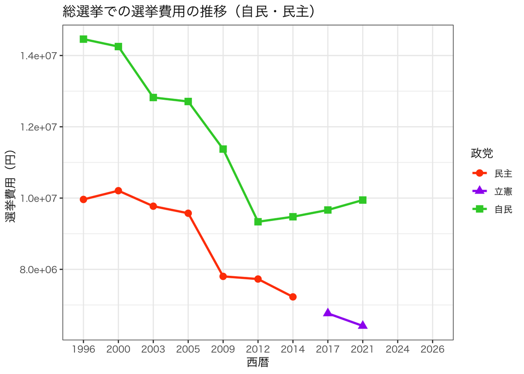

```r
hr %>%
   group_by(year, seito) |>
  summarise(Mean_exp = mean(exp, na.rm = TRUE)) |>
  filter(seito == "自民" | seito == "民主" |seito == "立憲") |>

   ggplot(aes(x = year,            # 共通するマッピング
              y = Mean_exp,        # 共通するマッピング
              color = seito)) +    # 共通するマッピング
   geom_line(aes(group = seito),
             size = 1) +
   geom_point(aes(shape = seito),
              size = 3) +
  labs(x = "西暦",
       y = "選挙費用（円）",
       color = "政党",
       shape = "政党") +
  ggtitle("総選挙での選挙費用の推移（自民・民主）") +
  scale_color_manual(values = c("民主" = "orangered",
    "立憲" = "purple",
    "自民" = "limegreen")) +
  theme_bw(base_family = "HiraKakuProN-W3")
```

- 自民党と民主党それぞの選挙費用の平均値を計算してみる

```r
hr |>
  filter (seito == "自民" | seito == "民主" |seito == "立憲") |>
  group_by(seito) |>
  summarise(Mean_exp = mean(exp, na.rm = TRUE))
```

```
# A tibble: 3 × 2
  seito  Mean_exp
  <chr>     <dbl>
1 民主   8888738.
2 立憲   6493454.
3 自民  11544302.
```

### グループごとのケース数を知りたい場合: `n()`

#### 政党別立候補者数の推移

```r
hr |>
  filter(seito == "自民" | seito == "民主" |seito == "立憲") |>
  group_by(year, seito) |>
  summarise(Mean_exp = mean(exp, na.rm = TRUE),
            Cand_number = n())
```

```
# A tibble: 21 × 4
# Groups:   year [11]
   year  seito  Mean_exp Cand_number
   <fct> <chr>     <dbl>       <int>
 1 1996  民主   9961458.         143
 2 1996  自民  14460093.         288
 3 2000  民主  10207109.         242
 4 2000  自民  14251423.         271
 5 2003  民主   9772028.         267
 6 2003  自民  12821990.         277
 7 2005  民主   9574473.         289
 8 2005  自民  12710075.         290
 9 2009  民主   7802585.         271
10 2009  自民  11374974.         291
# ℹ 11 more rows
```

- `ggplot()` 関数を使って自民党と民主党それぞれの立候補者数を総選挙ごとに可視化してみる
- `geom_tex()`関数を使って立候補者数を図に表示することも可能

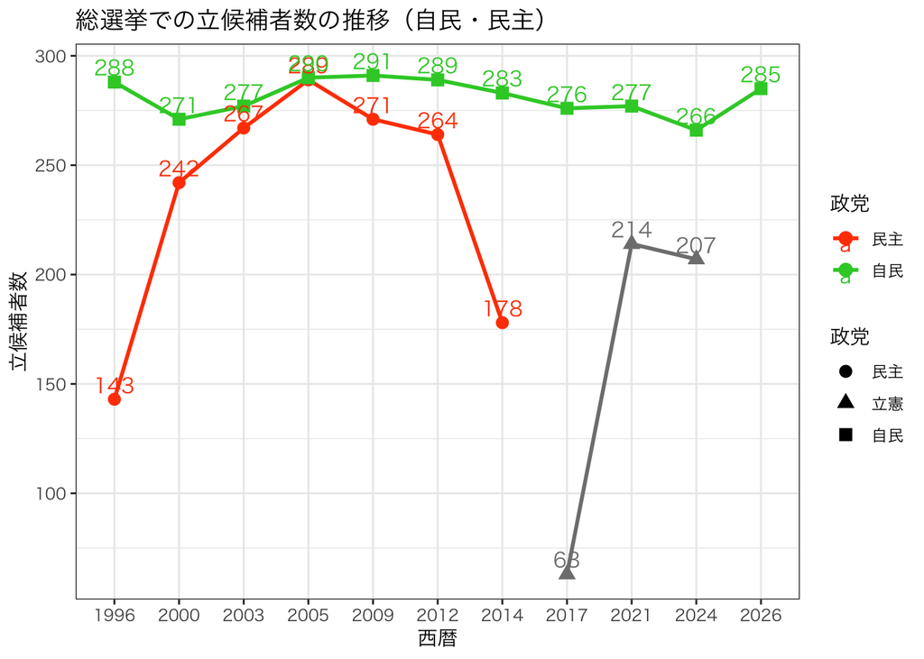

```r
hr %>%
   filter(seito == "自民" | seito == "民主"　|seito == "立憲") |>
  group_by(year, seito) |>
  summarise(Mean_exp = mean(exp, na.rm = TRUE),
            Cand_number = n()) |>

   ggplot(aes(x = year,            # 共通するマッピング
              y = Cand_number,        # 共通するマッピング
              color = seito)) +    # 共通するマッピング
   geom_line(aes(group = seito),
             size = 1) +
   geom_point(aes(shape = seito),
              size = 3) +
  labs(x = "西暦",
       y = "立候補者数",
       color = "政党",
       shape = "政党") +
  geom_text(aes(y = Cand_number + 3, label = Cand_number),
            size = 4, vjust = 0)　+
  ggtitle("総選挙での立候補者数の推移（自民・民主）") +
  scale_color_manual(values = c("民主" = "orangered",
    "立民" = "purple",
    "自民" = "limegreen")) +
  theme_bw(base_family = "HiraKakuProN-W3")
```

```r
hr |>
  filter(seito == "自民" | seito == "民主" | seito == "立憲") |>
  group_by(seito) |>
  summarize(Cand_number = n())
```

```
# A tibble: 3 × 2
  seito Cand_number
  <chr>       <int>
1 民主         1654
2 立憲          484
3 自民         3093
```

## 3.3 より短いコードで入力可能: `across()`

- `across()` 関数を利用することで、複数の変数に対して複数の記述統計量をより短いコードで計算することが可能

```r
names(hr)
```

```
 [1] "year"          "pref"          "ku"            "kun"
 [5] "rank"          "wl"            "nocand"        "seito"
 [9] "j_name"        "name"          "previous"      "gender"
[13] "age"           "exp"           "status"        "vote"
[17] "voteshare"     "eligible"      "turnout"       "seshu_dummy"
[21] "jiban_seshu"   "nojiban_seshu"
```

```r
hr |>
  summarise(previous_Mean = mean(previous, na.rm = TRUE),
            previous_SD   = mean(previous, na.rm = TRUE),
            age_Mean      = mean(age, na.rm = TRUE),
            age_SD        = mean(age, na.rm = TRUE),
            exp_Mean      = mean(exp, na.rm = TRUE),
            exp_SD        = mean(exp, na.rm = TRUE))
```

```
# A tibble: 1 × 6
  previous_Mean previous_SD age_Mean age_SD exp_Mean   exp_SD
          <dbl>       <dbl>    <dbl>  <dbl>    <dbl>    <dbl>
1          1.52        1.52     51.6   51.6 7125574. 7125574.
```

- この作業は、`across()` 関数を使うと 4 行でよい

```r
hr |>
  summarise(across(previous:exp,
                   .fns = list(Mean = ~mean(.x, na.rm = TRUE),
                               SD = ~mean(.x, na.rm = TRUE))))
```

```
# A tibble: 1 × 8
  previous_Mean previous_SD gender_Mean gender_SD age_Mean age_SD exp_Mean
          <dbl>       <dbl>       <dbl>     <dbl>    <dbl>  <dbl>    <dbl>
1          1.52        1.52          NA        NA     51.6   51.6 7125574.
# ℹ 1 more variable: exp_SD <dbl>
```

## 3.4 変数の作成: `mutate()`

`mutate()`関数の使い方 `データフレーム名 |>`  
`mutate(新しい変数名 = 計算式)`

- 新しい変数名が既に存在するの変数名だと  
  → 既存の変数が上書きされてしまう
- 既存にない変数名だと  
  → 新しい変数が最後の変数として追加される
- hr の 選挙費用 (`exp`) を有権者数 (`eligible`) で割り「有権者一人あたりに費やす選挙費用」(`exppv`) を作成する
- `dplyr` を使わずにこの処理を行う場合、以下のようなコードとなる

```r
hr$exppv <- hr$exp / hr$eligible
```

```r
names(hr)
```

```
 [1] "year"          "pref"          "ku"            "kun"
 [5] "rank"          "wl"            "nocand"        "seito"
 [9] "j_name"        "name"          "previous"      "gender"
[13] "age"           "exp"           "status"        "vote"
[17] "voteshare"     "eligible"      "turnout"       "seshu_dummy"
[21] "jiban_seshu"   "nojiban_seshu" "exppv"
```

- 最後に `exppv` が追加されている
- `dplyr::mutate()` を使うと次のようなコードになる

```r
hr |>
  dplyr::mutate(exppv = exp / eligible)
```

```
# A tibble: 11,892 × 23
   year  pref  ku    kun   rank  wl    nocand seito j_name name  previous gender
   <fct> <chr> <chr> <fct> <fct> <fct>  <dbl> <chr> <chr>  <chr>    <dbl> <chr>
 1 1996  愛知  aichi 1     7     0          7 無所  浅野光雪…… ASAN…        0 male
 2 1996  愛知  aichi 1     6     0          7 国民党…… 山田浩 YAMA…        0 male
 3 1996  愛知  aichi 1     5     0          7 文化フォ… 伊東マサコ… ITO,…        0 female
 4 1996  愛知  aichi 1     4     0          7 共産  岩中美保子… IWAN…        0 female
 5 1996  愛知  aichi 1     3     0          7 民主  佐藤泰介…… SATO…        1 male
 6 1996  愛知  aichi 1     2     0          7 自民  今枝敬雄…… IMAE…        3 male
 7 1996  愛知  aichi 1     1     1          7 新進  河村たかし… KAWA…        1 male
 8 1996  愛知  aichi 2     8     0          8 国民党…… 山崎義章…… YAMA…        0 male
 9 1996  愛知  aichi 2     7     0          8 無所  村松陽一…… MURA…        0 male
10 1996  愛知  aichi 2     6     0          8 文化フォ… 石川和己…… ISHI…        0 male
# ℹ 11,882 more rows
# ℹ 11 more variables: age <dbl>, exp <dbl>, status <fct>, vote <dbl>,
#   voteshare <dbl>, eligible <dbl>, turnout <dbl>, seshu_dummy <dbl>,
#   jiban_seshu <chr>, nojiban_seshu <chr>, exppv <dbl>
```

- 出力される画面に `exppv` がない  
  → 新しく追加された `exppv` が最後の列なので、画面に収まらないから
- `exppv` は問題なく追加されており、出力画面の下段に省略されている変数名に含まれている

```r
names(hr)
```

```
 [1] "year"          "pref"          "ku"            "kun"
 [5] "rank"          "wl"            "nocand"        "seito"
 [9] "j_name"        "name"          "previous"      "gender"
[13] "age"           "exp"           "status"        "vote"
[17] "voteshare"     "eligible"      "turnout"       "seshu_dummy"
[21] "jiban_seshu"   "nojiban_seshu" "exppv"
```

# 4. 変数の re-coding

## 4.1 `if_else()`

- 変数の `re-coding` に使う関数

`if_else()`関数の使い方 `if_else(条件式, TRUE の場合の戻り値, FALSE の場合の戻り値)`

- 具体的な事例を示してみよう
- 例えば、`hr` の変数 `status` の値は 0, 1, 2 の 3 つである

| 変数名 | 詳細 |
| --- | --- |
| status | 候補者のステータス: 0 = 非現職、1 現職、2 = 元職 |

- `status` 変数でデータをグルーピングし、`vote` と `exp` の平均値を計算してみる

```r
hr |>
  group_by(status) |>
  summarise(Mean_vote = mean(vote, na.rm = TRUE),
            Mean_exp = mean(exp, na.rm = TRUE))
```

```
# A tibble: 3 × 3
  status Mean_vote  Mean_exp
  <fct>      <dbl>     <dbl>
1 0         32304.  4714481.
2 1         87914. 10650551.
3 2         67961.  8095759.
```

```r
hr <- hr |>
  mutate(inc = if_else(status == 1, "現職", "非現職")) # status の値が 1 なら inc の値は 1、それ以外は 0 という意味
```

- `table()` 関数と `unique()` 関数を使って、変数 `inc` が正しく作成されたかどうかチェックする

```r
table(hr$status, hr$inc)
```

```
    現職 非現職
  0    0   6808
  1 4315      0
  2    0    769
```

```r
unique(hr$inc)
```

```
[1] "非現職" "現職"
```

- `re-coding` する場合、既存の変数（この場合だと `status`）を上書せず、新しい変数（この場合だと `inc`）として追加することが望ましい
- `inc` 変数でデータをグルーピングし、`vote` と `exp` の平均値を計算してみる

```r
hr |>
  group_by(inc) |>
  summarise(Mean_vote = mean(vote, na.rm = TRUE),
            Mean_exp = mean(exp, na.rm = TRUE))
```

```
# A tibble: 2 × 3
  inc    Mean_vote  Mean_exp
  <chr>      <dbl>     <dbl>
1 現職      87914. 10650551.
2 非現職    35923.  5068651.
```

## 4.2 `case_when()`

- 1 つの条件を `re-coding` したいとき・・・`if_else()` 関数を使う
- 2 つ以上の条件を `re-coding` したいとき・・・`case_when()` 関数を使う

`case_when`関数の使い方 `データフレーム名 |>`  
`mutate(新しい変数名 = case_when(条件1 ~ 新しい値,`  
`条件2 ~ 新しい値,`  
`......`  
`TRUE ~ 新しい値)`

- `TRUE ~ 新しい値`は「上記の条件全てが満たされない場合の値」を意味する
- `hr` の 変数 `status` の値 (1, 2, 0) を日本語（現職・元職・新人）に変換し変数 `status_j` として追加する

```r
hr %>%
  mutate(status_j = case_when(status == "1" ~ "現職",
                              status == "2" ~ "元職",
                            　TRUE  ~ "新人")) %>% # 現職、元職以外は「新人」と指定
  group_by(ステータス = status_j) %>%
  summarise(平均得票数 = mean(vote, na.rm = TRUE),
            候補者数         = n())
```

```
# A tibble: 3 × 3
  ステータス 平均得票数 候補者数
  <chr>           <dbl>    <int>
1 元職           67961.      769
2 新人           32304.     6808
3 現職           87914.     4315
```

## 4.3 `%in%`

- `hr` の変数 `seito` は候補者の所属政党を示している

| 変数名 | 詳細 |
| --- | --- |
| seito | 候補者の所属政党 |

- `hr` から 2021年総選挙のデータだけを抜き出して、`seito` の値を確認してみる

```r
hr2021 <- hr |>
  filter(year == 2021)
```

```r
unique(hr2021$seito)
```

```
 [1] "Ｎ党" "立憲" "自民" "国民" "維新" "共産" "れい" "無所" "諸派" "社民"
[11] "公明"
```

```r
hr2021 %>%
  mutate(party = case_when(seito == "自民" ~ "自民党",
                        　 seito == "公明" ~ "公明党",
                        　 seito == "立憲" ~ "立憲民主党",
                        　 seito == "維新" ~ "日本維新の会",
                        　 seito == "国民" ~ "国民民主党",
                        　 seito == "N党" ~ "NHK党",
                        　 seito == "れい" ~ "れいわ新撰組",
                        　 seito == "社民" ~ "社会民主党",
                        　 seito == "共産" ~ "共産党",
                        　 seito == "無所" ~ "無所属",
                           TRUE  ~ "諸派")) %>%
  group_by(政党 = party) %>%
  summarise(得票総数             = sum(vote, na.rm = TRUE),
            候補者数             = n(),
            一人あたり得票平均数 = mean(vote, na.rm = TRUE))
```

```
# A tibble: 10 × 4
   政党         得票総数 候補者数 一人あたり得票平均数
   <chr>           <dbl>    <int>                <dbl>
 1 れいわ新撰組   248280       12               20690
 2 公明党         872931        9               96992.
 3 共産党        2640801      105               25150.
 4 国民民主党    1245719       21               59320.
 5 日本維新の会  4802793       94               51094.
 6 無所属        2269166       80               28365.
 7 社会民主党     313193        9               34799.
 8 立憲民主党   17215620      214               80447.
 9 自民党       27626157      277               99733.
10 諸派           222368       36                6177.
```

- 「新しい値」(`TRUE ~ ""`) は条件の数だけ存在する必要はない
- 例えば、変数 `seito` の値が”自民”か”公明”なら”政権与党”
- それ以外は”野党”に変更
- その結果を「与野党」という名の新しい変数として追加してみる

```r
hr2021 %>%
  mutate(party = case_when(seito == "自民" ~ "政権与党",
                        　 seito == "公明" ~ "政権与党",
                           TRUE  ~ "野党")) %>%
  group_by(与野党 = party) %>%
  summarise(得票総数             = sum(vote, na.rm = TRUE),
            候補者数             = n(),
            一人あたり得票平均数 = mean(vote, na.rm = TRUE))
```

```
# A tibble: 2 × 4
  与野党   得票総数 候補者数 一人あたり得票平均数
  <chr>       <dbl>    <int>                <dbl>
1 政権与党 28499088      286               99647.
2 野党     28957940      571               50714.
```

- ここでは戻り値が 2 種類（“政権与党”か”野党”）のみ  
  → `if_else()` 関数を使うこともできる

#### `%in%`演算子が使える

- 左側の値が右側のベクトルに含まれていれば・・・TRUE
- 含まれていなければ・・・FALSE
- `hr2021` の変数 `seito` が”自民”か”公明”のいずれかに該当するか確認する

```r
head(hr2021$seito %in% c("自民", "公明"))
```

```
[1] FALSE FALSE  TRUE  TRUE FALSE  TRUE
```

```r
hr2021 %>%
  mutate(party = if_else(seito %in% c("自民", "公明"), "政権与党", "野党")) %>%
  group_by(与野党 = party) %>%
  summarise(得票総数             = sum(vote, na.rm = TRUE),
            候補者数             = n(),
            一人あたり得票平均数 = mean(vote, na.rm = TRUE))
```

```
# A tibble: 2 × 4
  与野党   得票総数 候補者数 一人あたり得票平均数
  <chr>       <dbl>    <int>                <dbl>
1 政権与党 28499088      286               99647.
2 野党     28957940      571               50714.
```

## 4.4 `recode()` 関数

- `if_else()` と `case_when()` は書き方がやや複雑
- `recode()` は使う条件式が `==` のみの場合、`if_else()` や `case_when()` と代替可能

```r
hr2021 %>%
  mutate(party = recode(seito,
                        "自民"   =  "政権与党",
                        "公明"   =  "政権与党",
                        .default =  "野党")) %>%
  group_by(与野党 = party) %>%
  summarise(得票総数             = sum(vote, na.rm = TRUE),
            候補者数             = n(),
            一人あたり得票平均数 = mean(vote, na.rm = TRUE))
```

```
# A tibble: 2 × 4
  与野党   得票総数 候補者数 一人あたり得票平均数
  <chr>       <dbl>    <int>                <dbl>
1 政権与党 28499088      286               99647.
2 野党     28957940      571               50714.
```

- `.default = ""`: いずれの条件にも該当しない場合の値を意味

# 4. 欠損値への対処法

- 世論調査などのデータを扱う場合、欠損値が `99` や `999` などで表示されることが多い
- 例えば、次の架空データについて考えてみよう

```r
df1 <- tibble(id      = 1:10,
              age     = c(19, 20, 22, 999, 35, 45, 50, 60, 70, 999),
              college = c(1, 0, 0, 1, 1, 99, 1, 1, 99, 0))
df1
```

```
# A tibble: 10 × 3
      id   age college
   <int> <dbl>   <dbl>
 1     1    19       1
 2     2    20       0
 3     3    22       0
 4     4   999       1
 5     5    35       1
 6     6    45      99
 7     7    50       1
 8     8    60       1
 9     9    70      99
10    10   999       0
```

| **変数** | **解説** |
| --- | --- |
| id: | ID番号 |
| age: | 年齢、999 = 欠損値 |
| college: | 1 = 大卒、0 = それ以外、99 = 欠損値 |

- 回答者の年齢と学歴の平均値を出力してみよう

```r
mean(df1$age)
```

```
[1] 231.9
```

- 回答者の平均年齢は 231.9歳!？

```r
mean(df1$college)
```

```
[1] 20.3
```

- 回答者の大卒率は 20.3%?
- データ分析の前に欠損値の確認と処理は必須
- こに作業を怠ると研究結果に大きな歪みが生じる
- 特に、欠損値が `NA` でなく、`99` や `999` の場合には注意が必要

#### 欠損値の処置方法

##### Step 1:

- 変数 `AGE` を作成し、`age` が `39` 以下なら `1`、それ以外は `0` と指定
- `age` が `999` なら `NA` と指定
- `mutate()` 内に `case_when()` を使って指定する

```r
df1 %>%
  mutate(AGE  = case_when(age == 999 ~ NA, # age が 999 なら NA
                          age <=  39 ~ 1,     # age が 39 以下なら 1、それ以外は 0
                          TRUE       ~ 0))
```

- 次のようなエラーがでる！

エラーメッセージ  
Error in `mutate()`: ! Problem while computing `AGE = case_when(age == 999 ~ NA, age <= 39 ~ 1, TRUE ~ 0)`. Caused by error in `` names(message) <- `*vtmp*` ``: ! ‘names’ attribute [1] must be the same length as the vector [0]

- 原因は `NA` の設定: `age == 999 ~ NA`
- `R` において欠損値は `NA` のみ
- しかし `tidyverse` の世界では、`NA` は次の 2 種類ある  
  ・`numeric` 型の `NA`  
  ・`charcter` 型の `NA`
- 上のコードの場合、新たに作る変数 `AGE` の値は全て数値だから、`AGE` は `numeric` 型  
  → `age == 999 ~ NA_real_` と設定

```r
df1 %>%
  mutate(AGE  = case_when(age == 999 ~ NA_real_,  # age が 999 なら NA
                          age <=  39 ~ 1,           # age が 39 以下なら 1、それ以外は 0
                          TRUE       ~ 0))
```

```
# A tibble: 10 × 4
      id   age college   AGE
   <int> <dbl>   <dbl> <dbl>
 1     1    19       1     1
 2     2    20       0     1
 3     3    22       0     1
 4     4   999       1    NA
 5     5    35       1     1
 6     6    45      99     0
 7     7    50       1     0
 8     8    60       1     0
 9     9    70      99     0
10    10   999       0    NA
```

- うまく設定できた

##### Step 2:

- 変数 `COLLEGE` を作成し、`college` が `1` なら “大卒以上”、`0` は “大卒未満”、`99` なら `NA` と指定

```r
df1 %>%
  mutate(AGE  = case_when(age == 999 ~ NA_real_,
                          age <=  39 ~ 1,
                          TRUE       ~ 0),
         COLLEGE = case_when(college == 99 ~ NA,      # 99 なら NA
                            college == 1 ~ "大卒以上",  # college が 1 なら “大卒以上”、0 は “大卒未満”
                            TRUE          ~ "大卒未満"))
```

エラーメッセージ

- 原因は `NA` の設定: `college == 99 ~ NA`
- `NA` は次の 2 種類ある  
  ・`numeric` 型の `NA`  
  ・`charcter` 型の `NA`
- 上のコードの場合、新たに作る変数 `COLLEGE` の値は全て文字型だから、`COLLEGE` は `character` 型  
  → `college == 99 ~ NA_character_` と設定

```r
df1 %>%
  mutate(AGE  = case_when(age == 999 ~ NA_real_,
                          age <=  39 ~ 1,
                          TRUE       ~ 0),
         COLLEGE = case_when(college == 99 ~ NA_character_,  # 99 なら NA
                            college == 1 ~ "大卒以上",         # college が 1 なら “大卒以上”、0 は “大卒未満”
                            TRUE          ~ "大卒未満"))
```

```
# A tibble: 10 × 5
      id   age college   AGE COLLEGE
   <int> <dbl>   <dbl> <dbl> <chr>
 1     1    19       1     1 大卒以上
 2     2    20       0     1 大卒未満
 3     3    22       0     1 大卒未満
 4     4   999       1    NA 大卒以上
 5     5    35       1     1 大卒以上
 6     6    45      99     0 <NA>
 7     7    50       1     0 大卒以上
 8     8    60       1     0 大卒以上
 9     9    70      99     0 <NA>
10    10   999       0    NA 大卒未満
```

欠損値 (`NA`) の指定方法まとめ  
・`numeric` 型の `NA` の場合:  
`変数 == 値 ~ NA_real_`  
・`charcter` 型の `NA`:  
`変数 == 値 ~ NA_character_`

# 5. 練習問題

### 5.1 練習問題

- 衆院選挙データ (`hr96-26.csv`) を使って次の問題に答えなさい

#### Q5.1.1

- `group_by()` 関数と `ggplot()` 関数を使って総選挙 (1996-2024) の立候補者の平均年齢をすべての政党ごとに計算し線グラフで可視化しなさい

#### Q5.1.2

- 政党を自民党、民主党、公明党に絞って表示しなさい

#### Q5.1.3

- 総選挙 (1996-2024) の当選者の平均年齢を 3 つの政党（自民党、民主党、公明党）ごとに計算し線グラフで可視化しなさい
- その際、当選者の数も表示すること

### Q5.2:

- `group_by()` 関数と `ggplot()` 関数を使って総選挙 (1996-2024) の立候補者の平均年齢をすべての政党ごとに計算し線グラフで可視化しなさい

### Q5.3:

- 政党を自民党、民主党、公明党に絞って表示しなさい

### Q5.4:

- 総選挙 (1996-2024) の当選者の平均年齢を 3 つの政党（自民党、民主党、公明党）ごとに計算し線グラフで可視化しなさい。その際、当選者の数も表示すること。

### Q5.5

- 変数 `wl` の値は 0, 1, 2 の 3 つである

| 変数名 | 詳細 |
| --- | --- |
| wl | 選挙の当落: 1 = 小選挙区当選、2 = 復活当選、0 = 落選 |

- `if_else()` 関数を使って、小選挙区で当選した候補者を 1、小選挙区で落選した候補者を 0 とした小選挙区当選ダミー (`wlsmd`) を作成しなさい
- `table()` 関数と `unique()` 関数を使って、変数 `wlsmd` が正しく作成されたかどうかチェックしなさい

### Q5.6

- `filter()` 関数を使って2024年総選挙だけのデータを抜き出し、`if_else()` 関数を使って、自民党候補者を 1、それ以外の候補者を 0 とした自民党ダミー (`ldp`) を作成しなさい
- `table()` 関数と `unique()` 関数を使って、変数 `ldp` が正しく作成されたかどうかチェックしなさい

### Q5.7

- `filter()` 関数を使って2024年総選挙だけのデータを抜き出し、`mutate()` 関数、`if_else()` 関数、`%in%` 関数、`group_by()` 関数を使って、政権与党（自民党と公明党の合計）と野党候補者の平均年齢を比較して表示しなさい
- その際、政権与党と野党それぞれの候補者人数も表示しなさい

### Q5.8

- `filter()` 関数を使って2024年総選挙だけのデータを抜き出し、`mutate()` 関数、`if_else()` 関数、`%in%` 関数、`group_by()` 関数を使って、政権与党（自民党と公明党の合計）と野党の**当選者（比例復活当選者含む）**の平均年齢を比較して表示しなさい
- その際、政権与党と野党それぞれの候補者人数も表示しなさい

### Q5.9

- `filter()` 関数を使って2024年総選挙だけのデータを抜き出し、`mutate()` 関数、`case_when()` 関数と `group_by()` 関数を使って、自民党、公明党、立憲民主党、立憲民主党以外の野党の**当選者（比例復活当選者含む）**の平均年齢を比較して表示しなさい
- その際、自民党、公明党、立憲民主党、野党それぞれの候補者人数も表示しなさい

**参考文献**

[宋財泫 (Jaehyun Song)・矢内勇生 (Yuki Yanai)「私たちのR: ベストプラクティスの探究」](https://www.jaysong.net/RBook/)

[宋財泫「ミクロ政治データ分析実習（2022年度）」](https://www.jaysong.net/micro-book/)

[土井翔平（北海道大学公共政策大学院）「Rで計量政治学入門」](https://shohei-doi.github.io/quant_polisci/data-import.html)

[矢内勇生（高知工科大学）授業一覧](http://yukiyanai.github.io/teaching/)

浅野正彦, 矢内勇生.『Rによる計量政治学』オーム社、2018年

浅野正彦, 中村公亮.『初めてのRStudio』オーム社、2018年

Winston Chang, R Graphics Cookbook, O’Reilly Media, 2012.

Kieran Healy, DATA VISUALIZATION, Princeton, 2019

Kosuke Imai, Quantitative Social Science: An Introduction, Princeton University Press, 2017